# Manipulating Data in R

June 15, 2016

## Reshaping Data

In this module, we will show you how to:

1. Reshaping data from long (tall) to wide (fat)
2. Reshaping data from wide (fat) to long (tall)
3. Merging Data
4. Perform operations by a grouping variable

## Setup

We will show you how to do each operation in base R then show you how to use the `dplyr` or `tidyr` package to do the same operation (if applicable).

See the "Data Wrangling Cheat Sheet using `dplyr` and `tidyr`":

- https://www.rstudio.com/wp-content/uploads/2015/02/data-wrangling-cheatsheet.pdf

## Data used: Charm City Circulator

http://www.aejaffe.com/winterR_2016/data/Charm_City_Circulator_Ridership.csv

```r
circ = read.csv("http://www.aejaffe.com/winterR_2016/data/Charm_City_Circulator_Ridership.csv", as.is = TRUE)
head(circ, 2)
```

```
      day       date orangeBoardings orangeAlightings orangeAverage
1  Monday 01/11/2010             877             1027           952
2 Tuesday 01/12/2010             777              815           796
  purpleBoardings purpleAlightings purpleAverage greenBoardings
1              NA               NA            NA             NA
2              NA               NA            NA             NA
  greenAlightings greenAverage bannerBoardings bannerAlightings
1              NA           NA              NA               NA
2              NA           NA              NA               NA
  bannerAverage daily
1            NA   952
2            NA   796
```

## Creating a Date class from a character date

The `lubridate` package is great for dates:

```r
library(lubridate) # great for dates!
library(dplyr) # mutate/summarise functions
circ = mutate(circ, date = mdy(date))
sum( is.na(circ$date) ) # all converted correctly
```

```
[1] 0
```

```r
head(circ$date)
```

```
[1] "2010-01-11" "2010-01-12" "2010-01-13" "2010-01-14" "2010-01-15"
[6] "2010-01-16"
```

```r
class(circ$date)
```

```
[1] "Date"
```

## Making column names a little more separated

We will use `str_replace` from `stringr` to put periods in the column names.

```r
library(stringr)
cn = colnames(circ)
cn = cn %>%
  str_replace("Board", ".Board") %>%
  str_replace("Alight", ".Alight") %>%
  str_replace("Average", ".Average")
colnames(circ) = cn
cn
```

```
 [1] "day"               "date"              "orange.Boardings"
 [4] "orange.Alightings" "orange.Average"    "purple.Boardings"
 [7] "purple.Alightings" "purple.Average"    "green.Boardings"
[10] "green.Alightings"  "green.Average"     "banner.Boardings"
[13] "banner.Alightings" "banner.Average"    "daily"
```

## Removing the daily ridership

We want to look at each ridership, and will remove the `daily` column:

```r
circ$daily = NULL
```

## Reshaping data from wide (fat) to long (tall)

See http://www.cookbook-r.com/Manipulating_data/Converting_data_between_wide_and_long_format/

- Wide - multiple columns per observation
  - e.g. visit1, visit2, visit3

```
  id visit1 visit2 visit3
1  1     10      4      3
2  2      5      6     NA
```

- Long - multiple rows per observation

```
  id visit value
1  1     1    10
2  1     2     4
3  1     3     3
4  2     1     5
5  2     2     6
```

## Reshaping data from wide (fat) to long (tall): base R

The `reshape` command exists. It is a **confusing** function. Don't use it.

## Reshaping data from wide (fat) to long (tall): tidyr

`tidyr::gather` - puts column data into rows.

We want the column names into "`var`" variable in the output dataset and the value in "`number`" variable. We then describe which columns we want to "gather:"

```r
library(tidyr)
long = gather(circ, key = "var", value = "number",
              starts_with("orange"),
              starts_with("purple"),
              starts_with("green"),
              starts_with("banner"))
head(long, 2)
```

```
      day       date              var number
1  Monday 2010-01-11 orange.Boardings    877
2 Tuesday 2010-01-12 orange.Boardings    777
```

```r
table(long$var)
```

```
banner.Alightings    banner.Average  banner.Boardings  green.Alightings
             1146              1146              1146              1146
    green.Average   green.Boardings orange.Alightings    orange.Average
             1146              1146              1146              1146
 orange.Boardings purple.Alightings    purple.Average  purple.Boardings
             1146              1146              1146              1146
```

## Reshaping data from wide (fat) to long (tall): tidyr

Now each `var` is boardings, averages, or alightings. We want to separate these so we can have these by line.

```r
long = separate_(long, "var",
                 into = c("line", "type"),
                 sep = "[.]")
head(long, 3)
```

```
        day       date   line      type number
1    Monday 2010-01-11 orange Boardings    877
2   Tuesday 2010-01-12 orange Boardings    777
3 Wednesday 2010-01-13 orange Boardings   1203
```

```r
unique(long$line)
```

```
[1] "orange" "purple" "green"  "banner"
```

```r
unique(long$type)
```

```
[1] "Boardings"  "Alightings" "Average"
```

## Finding the First (or Last) record

```r
long = long %>% filter(!is.na(number) & number > 0)
first_and_last = long %>% arrange(date) %>% # arrange by date
  filter(type %in% "Boardings") %>% # keep boardings only
  group_by(line) %>% # group by line
  slice( c(1, n())) # select ("slice") first and last (n() command) lines
first_and_last %>%  head(4)
```

```
Source: local data frame [4 x 5]
Groups: line [2]

      day       date   line      type number
    (chr)     (date)  (chr)     (chr)  (dbl)
1  Monday 2012-06-04 banner Boardings    520
2  Friday 2013-03-01 banner Boardings    817
3 Tuesday 2011-11-01  green Boardings    887
4  Friday 2013-03-01  green Boardings   2592
```

## Reshaping data from long (tall) to wide (fat): tidyr

In `tidyr`, the `spread` function spreads rows into columns. Now we have a long data set, but we want to separate the Average, Alightings and Boardings into different columns:

```r
# have to remove missing days
wide = filter(long, !is.na(date))
wide = spread(wide, type, number)
head(wide)
```

```
     day       date   line Alightings Average Boardings
1 Friday 2010-01-15 orange       1643  1644.0      1645
2 Friday 2010-01-22 orange       1388  1394.5      1401
3 Friday 2010-01-29 orange       1322  1332.0      1342
4 Friday 2010-02-05 orange       1204  1217.5      1231
5 Friday 2010-02-12 orange        678   671.0       664
6 Friday 2010-02-19 orange       1647  1642.0      1637
```

## Reshaping data from long (tall) to wide (fat): tidyr

We can use `rowSums` to see if any values in the row is `NA` and keep if the row, which is a combination of date and line type has any non-missing data.

```r
# wide = wide %>%
#     select(Alightings, Average, Boardings) %>%
#     mutate(good = rowSums(is.na(.)) > 0)
namat = !is.na(select(wide, Alightings, Average, Boardings))
head(namat)
```

```
  Alightings Average Boardings
1       TRUE    TRUE      TRUE
2       TRUE    TRUE      TRUE
3       TRUE    TRUE      TRUE
4       TRUE    TRUE      TRUE
5       TRUE    TRUE      TRUE
6       TRUE    TRUE      TRUE
```

```r
wide$good = rowSums(namat) > 0
head(wide, 3)
```

```
     day       date   line Alightings Average Boardings good
1 Friday 2010-01-15 orange       1643  1644.0      1645 TRUE
2 Friday 2010-01-22 orange       1388  1394.5      1401 TRUE
3 Friday 2010-01-29 orange       1322  1332.0      1342 TRUE
```

## Reshaping data from long (tall) to wide (fat): tidyr

Now we can filter only the good rows and delete the `good` column.

```r
wide = filter(wide, good) %>% select(-good)
head(wide)
```

```
     day       date   line Alightings Average Boardings
1 Friday 2010-01-15 orange       1643  1644.0      1645
2 Friday 2010-01-22 orange       1388  1394.5      1401
3 Friday 2010-01-29 orange       1322  1332.0      1342
4 Friday 2010-02-05 orange       1204  1217.5      1231
5 Friday 2010-02-12 orange        678   671.0       664
6 Friday 2010-02-19 orange       1647  1642.0      1637
```

## Data Merging/Append in Base R

- Merging - joining data sets together - usually on key variables, usually "id"
- `merge()` is the most common way to do this with data sets
- `rbind`/`cbind` - row/column bind, respectively
  - `rbind` is the equivalent of "appending" in Stata or "setting" in SAS
  - `cbind` allows you to add columns in addition to the previous ways
- `t()` is a function that will transpose the data

## Merging

```r
base <- data.frame(id = 1:10, Age= seq(55,60, length=10))
base[1:2,]
```

```
  id      Age
1  1 55.00000
2  2 55.55556
```

```r
visits <- data.frame(id = rep(1:8, 3), visit= rep(1:3, 8),
                    Outcome = seq(10,50, length=24))
visits[1:2,]
```

```
  id visit  Outcome
1  1     1 10.00000
2  2     2 11.73913
```

## Merging

```r
merged.data <- merge(base, visits, by="id")
merged.data[1:5,]
```

```
  id      Age visit  Outcome
1  1 55.00000     1 10.00000
2  1 55.00000     3 23.91304
3  1 55.00000     2 37.82609
4  2 55.55556     2 11.73913
5  2 55.55556     1 25.65217
```

```r
dim(merged.data)
```

```
[1] 24  4
```

## Merging

```r
all.data <- merge(base, visits, by="id", all=TRUE)
tail(all.data)
```

```
   id      Age visit  Outcome
21  7 58.33333     2 48.26087
22  8 58.88889     2 22.17391
23  8 58.88889     1 36.08696
24  8 58.88889     3 50.00000
25  9 59.44444    NA       NA
26 10 60.00000    NA       NA
```

```r
dim(all.data)
```

```
[1] 26  4
```

## Joining in `dplyr`

- `?join` - see different types of joining for `dplyr`
- Let's look at https://www.rstudio.com/wp-content/uploads/2015/02/data-wrangling-cheatsheet.pdf

## Left Join

```r
lj = left_join(base, visits)
```

```
Joining by: "id"
```

```r
dim(lj)
```

```
[1] 26  4
```

```r
tail(lj)
```

```
   id      Age visit  Outcome
21  7 58.33333     2 48.26087
22  8 58.88889     2 22.17391
23  8 58.88889     1 36.08696
24  8 58.88889     3 50.00000
25  9 59.44444    NA       NA
26 10 60.00000    NA       NA
```

## Right Join

```r
rj = right_join(base, visits)
```

```
Joining by: "id"
```

```r
dim(rj)
```

```
[1] 24  4
```

```r
tail(rj)
```

```
   id      Age visit  Outcome
19  3 56.11111     1 41.30435
20  4 56.66667     2 43.04348
21  5 57.22222     3 44.78261
22  6 57.77778     1 46.52174
23  7 58.33333     2 48.26087
24  8 58.88889     3 50.00000
```

## Full Join

```r
fj = full_join(base, visits)
```

```
Joining by: "id"
```

```r
dim(fj)
```

```
[1] 26  4
```

```r
tail(fj)
```

```
   id      Age visit  Outcome
21  7 58.33333     2 48.26087
22  8 58.88889     2 22.17391
23  8 58.88889     1 36.08696
24  8 58.88889     3 50.00000
25  9 59.44444    NA       NA
26 10 60.00000    NA       NA
```

## Perform Operations By Groups: base R

The `tapply` command will take in a vector (`X`), perform a function (`FUN`) over an index (`INDEX`):

```r
args(tapply)
```

```
function (X, INDEX, FUN = NULL, ..., simplify = TRUE)
NULL
```

## Perform Operations By Groups: base R

Let's get the mean Average ridership by line:

```r
tapply(wide$Average, wide$line, mean, na.rm = TRUE)
```

```
   banner     green    orange    purple
 836.5637 1969.9668 3041.1924 4029.1071
```

## Perform Operations By Groups: dplyr

Let's get the mean Average ridership by line We will use `group_by` to group the data by line, then use `summarize` (or `summarise`) to get the mean Average ridership:

```r
gb = group_by(wide, line)
summarize(gb, mean_avg = mean(Average))
```

```
Source: local data frame [4 x 2]

    line  mean_avg
   (chr)     (dbl)
1 banner  836.5637
2  green 1969.9668
3 orange 3041.1924
4 purple 4029.1071
```

## Perform Operations By Groups: dplyr with piping

Using piping, this is:

```r
wide %>%
  group_by(line) %>%
  summarise(mean_avg = mean(Average))
```

```
Source: local data frame [4 x 2]

    line  mean_avg
   (chr)     (dbl)
1 banner  836.5637
2  green 1969.9668
3 orange 3041.1924
4 purple 4029.1071
```

## Perform Operations By Multiple Groups: dplyr

This can easily be extended using `group_by` with multiple groups. Let's define the year of riding:

```r
wide = wide %>% mutate(year = year(date),
                       month = month(date))
wide %>%
  group_by(line, year) %>%
  summarise(mean_avg = mean(Average))
```

```
Source: local data frame [13 x 3]
Groups: line [?]

     line  year  mean_avg
    (chr) (dbl)     (dbl)
1  banner  2012  894.8768
2  banner  2013  635.3833
3   green  2011 1455.1667
4   green  2012 2045.5870
5   green  2013 2028.5250
6  orange  2010 1890.7859
7  orange  2011 3061.6556
8  orange  2012 4079.9420
9  orange  2013 3322.6250
10 purple  2010 2577.1000
11 purple  2011 4026.9146
12 purple  2012 4850.8771
13 purple  2013 4045.3833
```

## Perform Operations By Multiple Groups: dplyr

We can then easily plot each day over time:

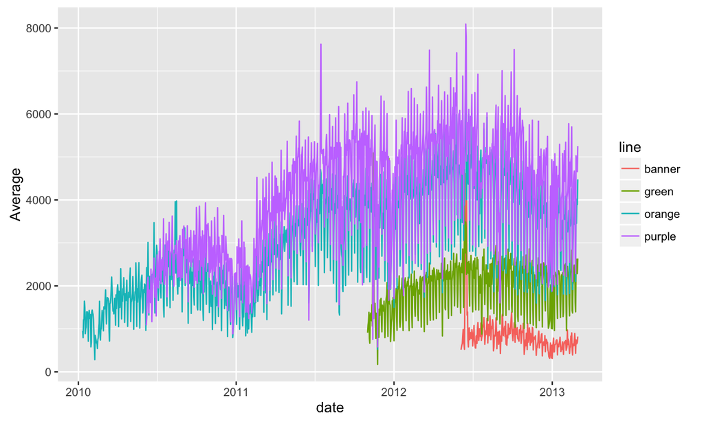

```r
library(ggplot2)
ggplot(aes(x = date, y = Average,
               colour = line), data = wide) + geom_line()
```

## Perform Operations By Multiple Groups: dplyr

Let's create the middle of the month (the 15th for example), and name it mon.

```r
mon = wide %>%
  dplyr::group_by(line, month, year) %>%
  dplyr::summarise(mean_avg = mean(Average))
mon = mutate(mon,
             mid_month = dmy(paste0("15-", month, "-", year)))
head(mon)
```

```
Source: local data frame [6 x 5]
Groups: line, month [6]

    line month  year  mean_avg  mid_month
   (chr) (dbl) (dbl)     (dbl)     (date)
1 banner     1  2013  610.3226 2013-01-15
2 banner     2  2013  656.4643 2013-02-15
3 banner     3  2013  822.0000 2013-03-15
4 banner     6  2012 1288.1296 2012-06-15
5 banner     7  2012  874.4839 2012-07-15
6 banner     8  2012  929.4355 2012-08-15
```

## Perform Operations By Multiple Groups: dplyr

We can then easily plot the mean of each month to see a smoother output:

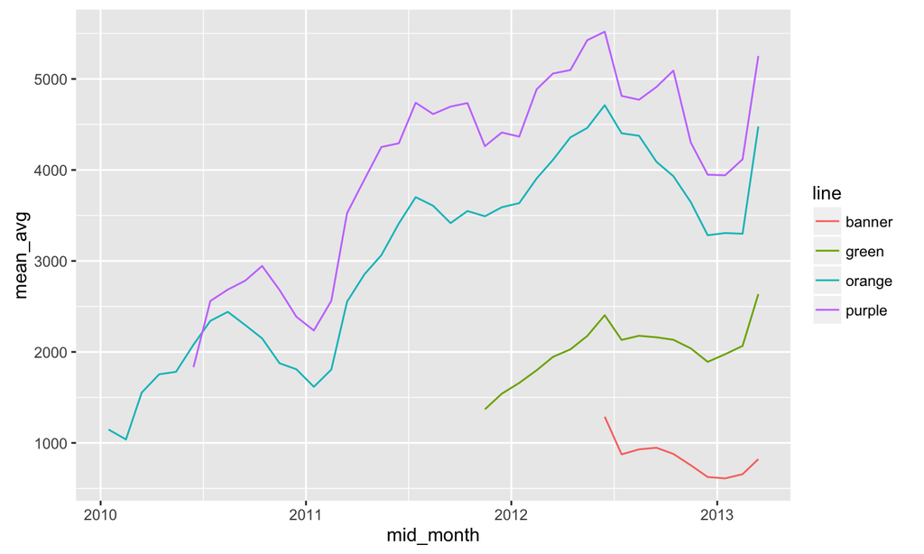

```r
ggplot(aes(x = mid_month,
               y = mean_avg,
               colour = line), data = mon) + geom_line()
```

## Bonus! Points with a smoother!

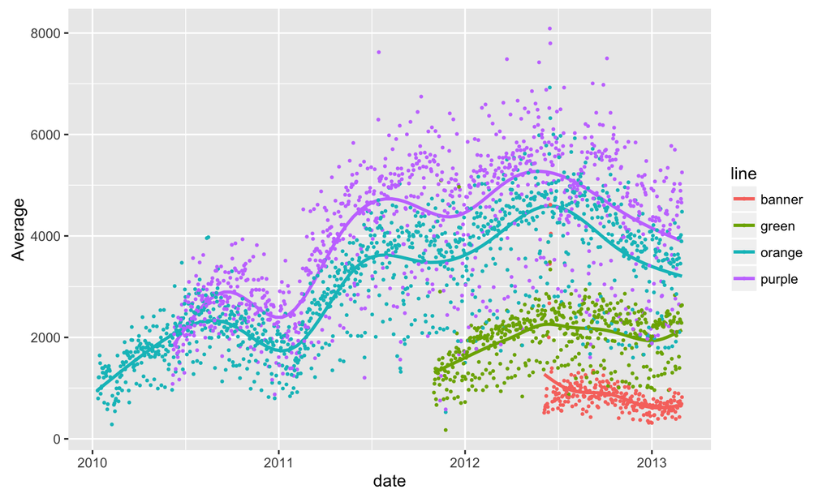

```r
ggplot(aes(x = date, y = Average, colour = line),
           data = wide) + geom_smooth(se = FALSE) +
  geom_point(size = .5)
```

## Extra `group_by` examples

## `group_by`

`group_by` is a form of replacement for `tapply` (not a complete replacement).

Example using Bike Lanes: http://www.aejaffe.com/summerR_2016/data/Bike_Lanes.csv

```r
bike = read.csv(
  "http://www.aejaffe.com/summerR_2016/data/Bike_Lanes.csv",
  as.is = TRUE)
```

## Summarizing data with `group_by` and `summarize`

You commonly need to run `group_by` with `summarize`.

Average bike length BY project:

```r
bike %>%
  group_by(project) %>%
  summarise(mean(length)) # get the average length
```

```
Source: local data frame [13 x 2]

                     project mean(length)
                       (chr)        (dbl)
1                                214.3288
2      CHARM CITY CIRCULATOR     276.6658
3                COLLEGETOWN     320.6836
4        COLLEGETOWN NETWORK     213.6373
5   ENGINEERING CONSTRUCTION     512.0976
6     GUILFORD AVE BIKE BLVD     197.2782
7                MAINTENANCE    1942.1523
8      OPERATION ORANGE CONE     250.0784
9  PARK HEIGHTS BIKE NETWORK     283.2252
10          PLANNING TRAFFIC     209.4289
11    SOUTHEAST BIKE NETWORK     210.8283
12                   TRAFFIC     419.5288
13           TRAFFIC CALMING     268.5314
```

## Naming columns in output in `summarize`

Using `summarise/summarize(my_new_column_name = output )` allows you to name the column in the output:

```r
bike %>%
  group_by(project) %>%
  summarize(mean_length = mean(length)) %>%
  head(4) # head ONLY for slide printing
```

```
Source: local data frame [4 x 2]

                project mean_length
                  (chr)       (dbl)
1                          214.3288
2 CHARM CITY CIRCULATOR    276.6658
3           COLLEGETOWN    320.6836
4   COLLEGETOWN NETWORK    213.6373
```